# R Notebook

```r
#print(dJSU(x, mu=16.8475, sigma=1.7560, nu=2.439, tau=2.742))
```

```r
# Fit different distributions
fit_bccg <- gamlss(bmi10 ~ 1, family=BCCG)
```

```
GAMLSS-RS iteration 1: Global Deviance = 1399.911
GAMLSS-RS iteration 2: Global Deviance = 1386.495
GAMLSS-RS iteration 3: Global Deviance = 1384.593
GAMLSS-RS iteration 4: Global Deviance = 1384.462
GAMLSS-RS iteration 5: Global Deviance = 1384.451
GAMLSS-RS iteration 6: Global Deviance = 1384.45
```

```r
fit_jsu <- gamlss(bmi10 ~ 1, family=JSU)
```

```
GAMLSS-RS iteration 1: Global Deviance = 1437.847
GAMLSS-RS iteration 2: Global Deviance = 1408.338
GAMLSS-RS iteration 3: Global Deviance = 1397.748
GAMLSS-RS iteration 4: Global Deviance = 1393.98
GAMLSS-RS iteration 5: Global Deviance = 1391.895
GAMLSS-RS iteration 6: Global Deviance = 1390.445
GAMLSS-RS iteration 7: Global Deviance = 1389.406
GAMLSS-RS iteration 8: Global Deviance = 1388.686
GAMLSS-RS iteration 9: Global Deviance = 1388.133
GAMLSS-RS iteration 10: Global Deviance = 1387.706
GAMLSS-RS iteration 11: Global Deviance = 1387.321
GAMLSS-RS iteration 12: Global Deviance = 1387.017
GAMLSS-RS iteration 13: Global Deviance = 1386.771
GAMLSS-RS iteration 14: Global Deviance = 1386.569
GAMLSS-RS iteration 15: Global Deviance = 1386.403
GAMLSS-RS iteration 16: Global Deviance = 1386.263
GAMLSS-RS iteration 17: Global Deviance = 1386.146
GAMLSS-RS iteration 18: Global Deviance = 1386.046
GAMLSS-RS iteration 19: Global Deviance = 1385.961
GAMLSS-RS iteration 20: Global Deviance = 1385.924
```

```r
fit_tf <- gamlss(bmi10 ~ 1, family=TF)
```

```
GAMLSS-RS iteration 1: Global Deviance = 1436.441
GAMLSS-RS iteration 2: Global Deviance = 1429.596
GAMLSS-RS iteration 3: Global Deviance = 1428.3
GAMLSS-RS iteration 4: Global Deviance = 1428.077
GAMLSS-RS iteration 5: Global Deviance = 1428.04
GAMLSS-RS iteration 6: Global Deviance = 1428.034
GAMLSS-RS iteration 7: Global Deviance = 1428.033
GAMLSS-RS iteration 8: Global Deviance = 1428.033
```

```r
fit_lognorm <- gamlss(bmi10 ~ 1, family=LOGNO)
```

```
GAMLSS-RS iteration 1: Global Deviance = 1433.15
GAMLSS-RS iteration 2: Global Deviance = 1433.15
```

```r
fit_lo <- gamlss(bmi10 ~ 1, family=LO)
```

```
GAMLSS-RS iteration 1: Global Deviance = 1441.477
GAMLSS-RS iteration 2: Global Deviance = 1440.682
GAMLSS-RS iteration 3: Global Deviance = 1440.681
```

```r
fit_pe <- gamlss(bmi10 ~ 1, family=PE)
```

```
GAMLSS-RS iteration 1: Global Deviance = 1445.659
GAMLSS-RS iteration 2: Global Deviance = 1444.568
GAMLSS-RS iteration 3: Global Deviance = 1444.554
GAMLSS-RS iteration 4: Global Deviance = 1444.553
GAMLSS-RS iteration 5: Global Deviance = 1444.553
```

```r
fit_gamma <- gamlss(bmi10 ~ 1, family=GA)
```

```
GAMLSS-RS iteration 1: Global Deviance = 1448.24
GAMLSS-RS iteration 2: Global Deviance = 1448.24
```

```r
fit_norm <- gamlss(bmi10 ~ 1, family=NO)
```

```
GAMLSS-RS iteration 1: Global Deviance = 1484.827
GAMLSS-RS iteration 2: Global Deviance = 1484.827
```

```r
fit_wei <- gamlss(bmi10 ~ 1, family=WEI)
```

```
GAMLSS-RS iteration 1: Global Deviance = 1647.668
GAMLSS-RS iteration 2: Global Deviance = 1599.759
GAMLSS-RS iteration 3: Global Deviance = 1599.68
GAMLSS-RS iteration 4: Global Deviance = 1599.679
GAMLSS-RS iteration 5: Global Deviance = 1599.679
```

```r
fit_gu <- gamlss(bmi10 ~ 1, family=GU)
```

```
GAMLSS-RS iteration 1: Global Deviance = 1820.084
GAMLSS-RS iteration 2: Global Deviance = 1706.85
GAMLSS-RS iteration 3: Global Deviance = 1706.843
GAMLSS-RS iteration 4: Global Deviance = 1706.842
```

```r
fit_exp <- gamlss(bmi10 ~ 1, family=EXP)
```

```
GAMLSS-RS iteration 1: Global Deviance = 2600.461
GAMLSS-RS iteration 2: Global Deviance = 2600.461
```

```r
fit_lg <- gamlss(bmi10 ~ 1, family=LG)
```

```
GAMLSS-RS iteration 1: Global Deviance = 3063.916
GAMLSS-RS iteration 2: Global Deviance = 18736.19
GAMLSS-RS iteration 3: Global Deviance = 3069.654
GAMLSS-RS iteration 4: Global Deviance = 105720.1
GAMLSS-RS iteration 5: Global Deviance = 72334.08
GAMLSS-RS iteration 6: Global Deviance = 38958.57
GAMLSS-RS iteration 7: Global Deviance = 5993.726
GAMLSS-RS iteration 8: Global Deviance = 3067.627
GAMLSS-RS iteration 9: Global Deviance = 123685.7
GAMLSS-RS iteration 10: Global Deviance = 90299.25
GAMLSS-RS iteration 11: Global Deviance = 56914.77
GAMLSS-RS iteration 12: Global Deviance = 23577.06
GAMLSS-RS iteration 13: Global Deviance = 3073.618
GAMLSS-RS iteration 14: Global Deviance = 3070.101
GAMLSS-RS iteration 15: Global Deviance = 3076.712
GAMLSS-RS iteration 16: Global Deviance = 66281.59
GAMLSS-RS iteration 17: Global Deviance = 32914.64
GAMLSS-RS iteration 18: Global Deviance = 3065.293
GAMLSS-RS iteration 19: Global Deviance = 137052.9
GAMLSS-RS iteration 20: Global Deviance = 103666.4
```

```r
models <- list(fit_jsu, fit_tf, fit_lognorm, fit_lo, fit_pe, fit_gamma, fit_norm, fit_wei, fit_gu, fit_exp, fit_lg)

# Compare models
aic_values <- sapply(models, AIC)
print(aic_values)
```

```
 [1]   1393.924   1434.033   1437.150   1444.682   1450.553   1452.240   1488.827   1603.679
 [9]   1710.842   2602.461 103668.388
```

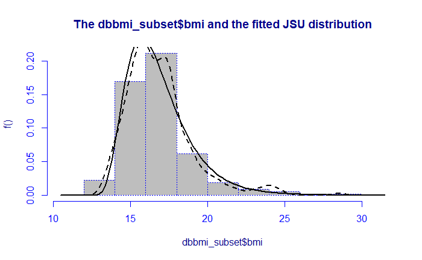

```r
# Select the model with the lowest AIC
selected_model <- models[[which.min(aic_values)]]
selected_model <- histDist(dbbmi_subset$bmi, "JSU", density=TRUE, line.col=c(1,1), line.ty=c(1,2))
```

```
          Summary of the Quantile Residuals
                           mean   =  1.773507e-08
                       variance   =  1.00295
               coef. of skewness  =  0.02547837
               coef. of kurtosis  =  3.240805
Filliben correlation coefficient  =  0.9965336
```

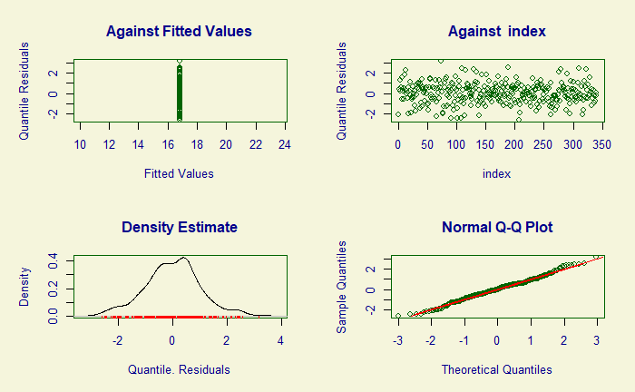

```r
plot(selected_model)
```

The choice of distribution can be justified by comparing the Akaike Information Criterion (AIC) values of the fitted models—the model with the lowest AIC is typically preferred as it suggests a good fit with relatively lower complexity.

### 3. Output Parameter Estimates and Interpretation

Finally, for the chosen model, we can output the parameter estimates and interpret them according to the distribution’s characteristics.

```r
# Output parameter estimates for the chosen model
summary(selected_model)
```

```
Family:  c("JSU", "Johnson SU")

Call:  gamlssML(formula = dbbmi_subset$bmi, family = "JSU")

Fitting method: "nlminb"


Coefficient(s):
             Estimate  Std. Error   t value   Pr(>|t|)
eta.mu    1.68445e+01 1.14111e-01 147.61571 < 2.22e-16 ***
eta.sigma 7.44327e-01 5.91375e-02  12.58638 < 2.22e-16 ***
eta.nu    1.92752e+01 2.96601e+03   0.00650    0.99481
eta.tau   8.94320e-01 1.11082e-01   8.05099 8.8818e-16 ***
---
Signif. codes:  0 ‘***’ 0.001 ‘**’ 0.01 ‘*’ 0.05 ‘.’ 0.1 ‘ ’ 1

 Degrees of Freedom for the fit: 4 Residual Deg. of Freedom   336
Global Deviance:     1385.36
            AIC:     1393.36
            SBC:     1408.67
```

```r
print(fit_jsu$mu.coefficients)
```

```
(Intercept)
   16.84751
```

Interpretation of the parameters will depend on the selected distribution. For example: - For a Normal distribution (`NO`), the parameters are the mean (`mu`) and standard deviation (`sigma`), representing the location and scale of the distribution. - For a Log-Normal distribution (`LOGNO`), `mu` and `sigma` represent the mean and standard deviation of the variable’s logarithm, indicating the distribution’s central tendency and spread on a log scale. - For a Gamma distribution (`GA`), the parameters might include a shape and a scale parameter, reflecting the distribution’s skewness and scale.

Refer to the GAMLSS book or documentation for specific interpretations of the parameters of your chosen distribution. The interpretation will help in understanding the characteristics of BMI distribution among Dutch boys aged 10 to 11, such as its central tendency, variability, and potential skewness.

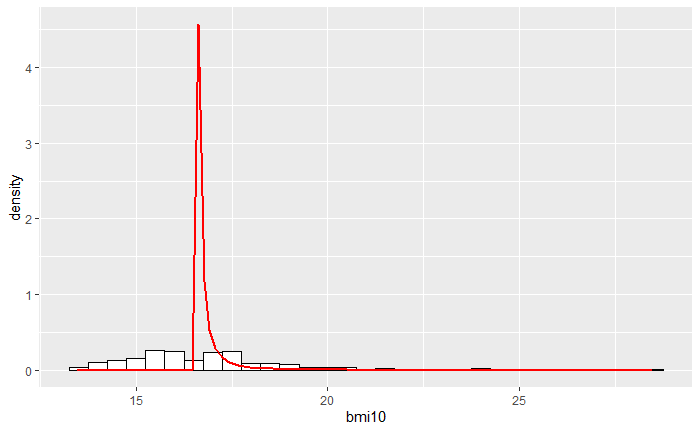

```r
# Function to calculate the fitted density
density_fitted <- function(x) {
  dJSU(x, mu=fit_jsu$mu.coefficients, sigma=fit_jsu$sigma.coefficients, nu=fit_jsu$nu.coefficients, tau=fit_jsu$tau.coefficients)
}

# Histogram with ggplot
p <- ggplot(dbbmi_subset, aes(x=bmi10)) +
  geom_histogram(aes(y=..density..), binwidth = 0.5, colour="black", fill="white")

# Add the fitted model curve
p <- p + stat_function(fun=density_fitted, colour="red", linewidth=1)
p
```

## Model Selection Week 8

Broad outline of approach for Q3

### Determining an Appropriate Distribution

1. Exploratory Data Analysis (EDA): Start with EDA to understand the distribution of your response variable and the relationships between explanatory variables and the response. This can include plotting histograms, box plots, and scatter plots.
2. Distribution Selection: Based on the EDA, you can hypothesize which distributions might fit your response variable. GAMLSS supports a wide range of distributions, so consider whether your data suggests normality, skewness, kurtosis, or zero-inflation which could guide your choice towards distributions like Gaussian, Binomial, Poisson, Negative Binomial, etc.
3. Fit Multiple Models: Initially, fit models with different distributions to your data. For instance, if you’re unsure whether your data are Poisson or Negative Binomial distributed, fit both models.
4. Distribution Comparison: Use criteria like the Akaike Information Criterion (AIC), Bayesian Information Criterion (BIC), or Generalized Akaike Information Criterion (GAIC) to compare models with different distributions. Lower values typically indicate a better fit to the data.

### Selecting Relevant Explanatory Variables

1. Univariate Analysis: Start by fitting simple models that include the response variable and one explanatory variable at a time. This can help identify variables that have no significant relationship with the response.
2. Multivariate Analysis: Include all significant variables in a multivariate GAMLSS model. Be mindful of multicollinearity among explanatory variables, as it can affect model estimates.
3. Variable Selection Techniques: Utilize backward elimination, forward selection, or both in a stepwise fashion to select relevant variables. Functions like stepGAIC can automate this process based on information criteria.